# Evaluación - Edición 2026

Este examen involucra la carga de datos, su exploración, manipulación y posterior producción de gráficos, tal como hemos visto a lo largo del curso. Para su realización se pueden consultar todos los materiales del curso y las ayudas internas de R. Sin embargo, por razones obvias, **no está permitido realizar consultas *online* o asistencia con *IA***.

Al final, debe entregar un script de R indexado por consigna y/o bloques de consignas. Utilice los comentarios para explicar brevemente cada línea o bloque de código, así como para explayarse en la explicación de alguna sección.

### Descarga de datos

[Descargue el archivo zip](https://github.com/pastornicolas/fundamentos_R/raw/refs/heads/main/unidad2/data/data_ev.zip) y extraiga los archivos necesarios para el examen.

### Carga y exploración de los datos

Utilizaremos una versión modificada del conjunto de datos `airquality` (Chambers et al., 1983), que contiene datos de mediciones diarias de la calidad del aire en Nueva York en el período de mayo a septiembre de 1973.

1. Cargue la tabla `airquality.csv` en una sesión de R.
2. Muestre las primeras 8 filas.
3. Muestre últimas 6 filas.
4. Imprima el nombre de todas las columnas.
5. Mencione de qué tipo es cada variable.

### Manipulacion de los datos

6. La tabla `humidity.csv` indica los valores de humedad relativa del aire para cada día y mes. Cargue la tabla e incorpore estos datos a la tabla `airquality` con la que viene trabajando.
7. Quite todos las filas con valores `NA` en cualquier columna.
8. Reordene las columnas en el siguiente orden: “Month”, “Day”, “Temp”, “Ozone”, “Wind”, “Humidity”, “Solar.R”.
9. Ordene la tabla por mes y por día, en ese orden, y de manera creciente. Ejemplo: Para el mes 5, la columna “Day” debería mostrar 1, 2, 3, etc; siguiendo esta lógica creciente para el resto de los meses.
10. Convierta los meses, indicados con número, a texto indicando su nombre (e.g. 5 = “Mayo”) y transforme la columna a factor, con los niveles (meses) ordenados en orden cronológico.
11. Reescriba el nombre de las filas para que coincida con los verdaderos índices (posiciones) de la tabla obtenida hasta ahora.
12. La columna “Temp” contiene el dato de la temperatura en grados Farenheit. Cree una nueva columna llamada “TempC” que contenga la temperatura en grados Celsius. La fórmula que relaciona ambas unidades es: `°C = (°F - 32) / 1.8`

### Funciones

13. Construya una función que haga la conversión de grados °F a grados °C y que la misma contemple un escenario donde el usuario no ingresa números. Ponga a prueba la función para transformar el valor de 100 grados °F a grados °C.

### Gráficos

14. Realice un gráfico de cajas (boxplot) que muestre el valor de la variable “Solar.R” (radiación solar) de Mayo a Septiembre, en ese orden.
15. Etiquete los ejes con nombres en español y agregue un título relevante. Utilice un color único para todas las cajas. Fuera de estas indicaciones, personalice el gráfico a su gusto.
16. Realice un gráfico de dispersión (*scatterplot*) entre `Ozono` y `Temperatura °C`. Personalízelo de manera que el gráfico final sea lo más similar posible a la siguiente figura:

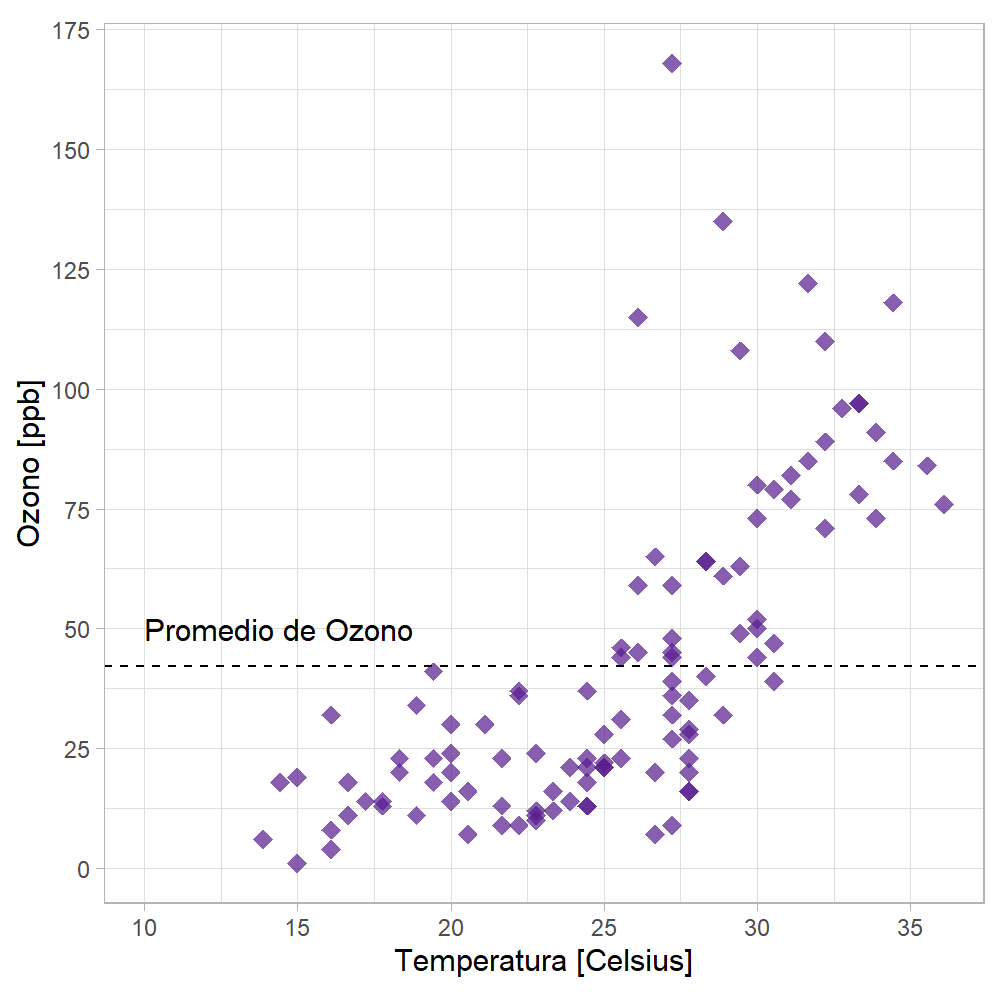

Preste atención a cómo la información se encuentra presentada, tanto en el gráfico en sí como en los ejes.

17. Exporte todos los gráficos realizados a formato `png` con una resolución de 200 ppi y de 1000 pixeles de alto y ancho. Los archivos deberán llamarse “grafico1.png” y “grafico2.png”.

### Ejercicio para entusiastas

Mediante un bucle `for` cree una nueva columna en la tabla `airquality` llamada “Solar.R.accum”. La misma debe representar la radiación solar acumulada día a día.

Tips:

- La tabla debe estar previamente ordenada cronológicamente.
- Debe primero crear la columna “Solar.R.accum” con valores `NA`.
- El primer valor de “Solar.R.accum” es igual al primer valor de “Solar.R”, ya que se corresponde con el primer día del primer mes de análisis.

### Evaluación

Envíe todos los archivos (script y gráficos), preferentemente comprimidos en un archivo zip, a la dirección npastor@unc.edu.ar. Indique en el asunto los apellidos y nombres de los estudiantes. En un escenario ideal, el script debería correr sin errores y seguir adecuadamente las consignas de la evaluación. No obstante, a no preocuparse demasiado, ya que se considerarán los intentos realizados!

### Debate final

Discutiremos sobre el rol que R ocupará en nuestras vidas en compañía de cerveza y/u otras bebidas espirituosas!

[figure not shown]